# Pre-Class 2

Kari Kusler

9/18/2018

Question 1

Question 2

The mean of exp.draws.02 is 4.847144 and the standard deviation is 4.896737.

The mean of exp.draws.5 is 0.2079173 and the standard deviation is 0.2017379.

The mean of exp.draws.7.3 is 0.1224047 and the standard deviation is 0.116555.

The mean of exp.draws.10 is 0.115676 and the standard deviation is 0.1238618.

Question 3a

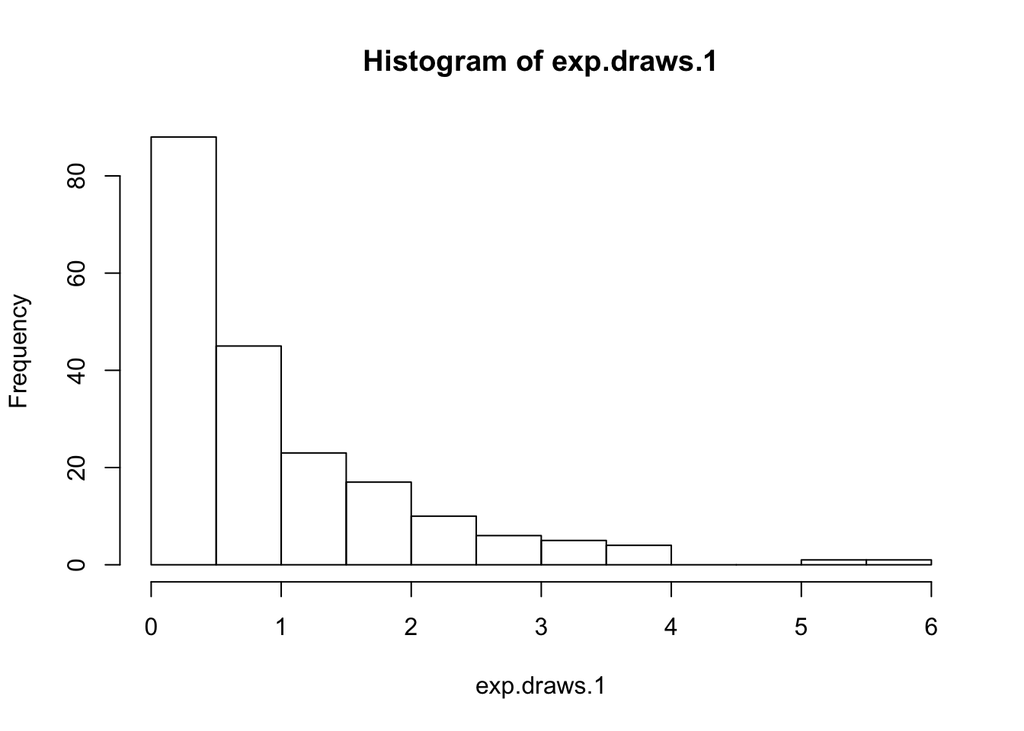

Question 3b

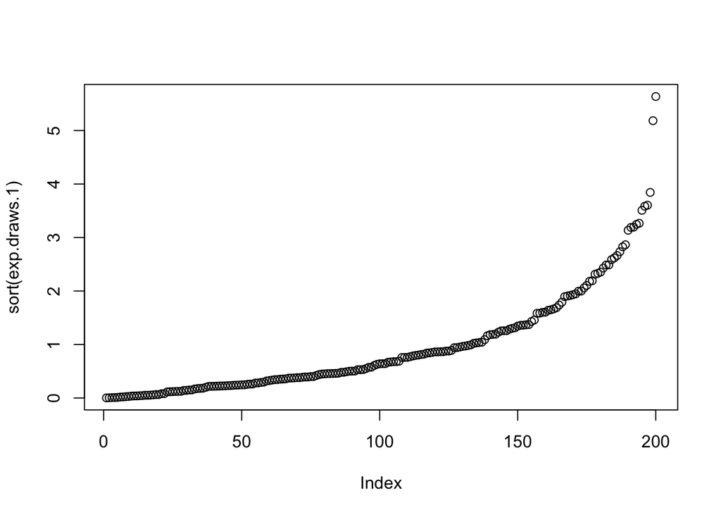

Question 3c

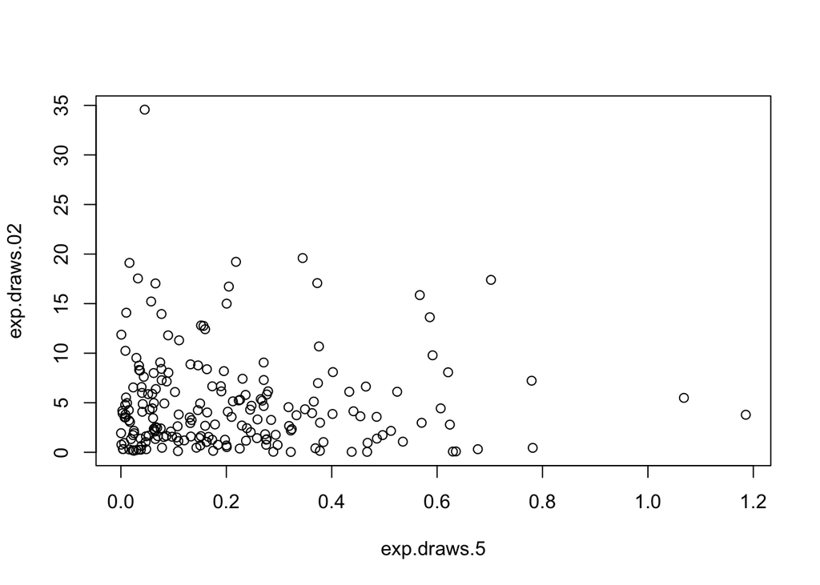

Question 4a

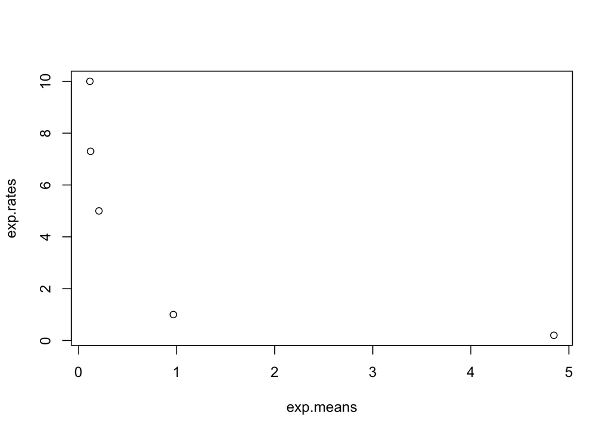

As the mean increases, the rate decreases.

Question 4b

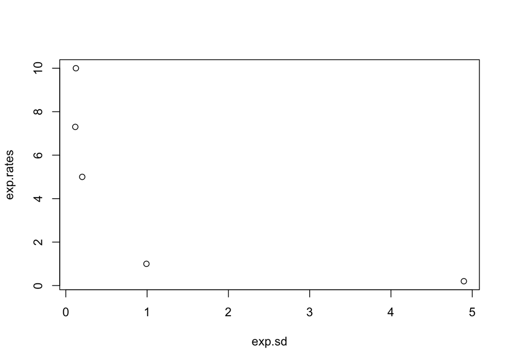

As the standard deviation increases, the rate decreases.

Question 4c

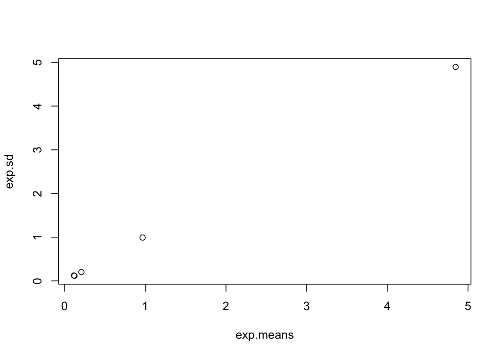

The mean and standard deviation are nearly equal.

Question 5a

The mean of big.exp.draws.1 is 0.999491 and the standard deviation is 0.9989396.

Question 5b

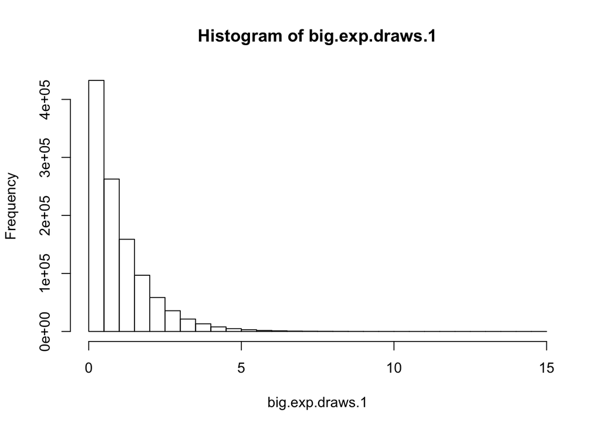

Question 5c

The mean of all entries in big.exp.draws.1 greater than 1 is 1.999256.

Question 5d

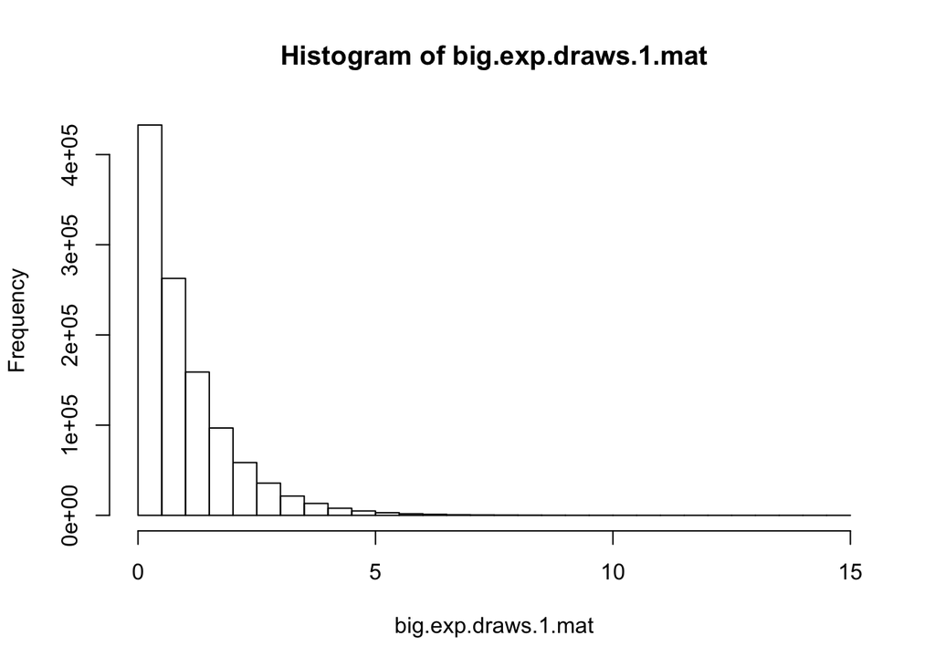

The information necessary to construct the histogram is saved in the histogram object.

Question 5e

The mean of column 371 is 0.9660588.

Question 5f

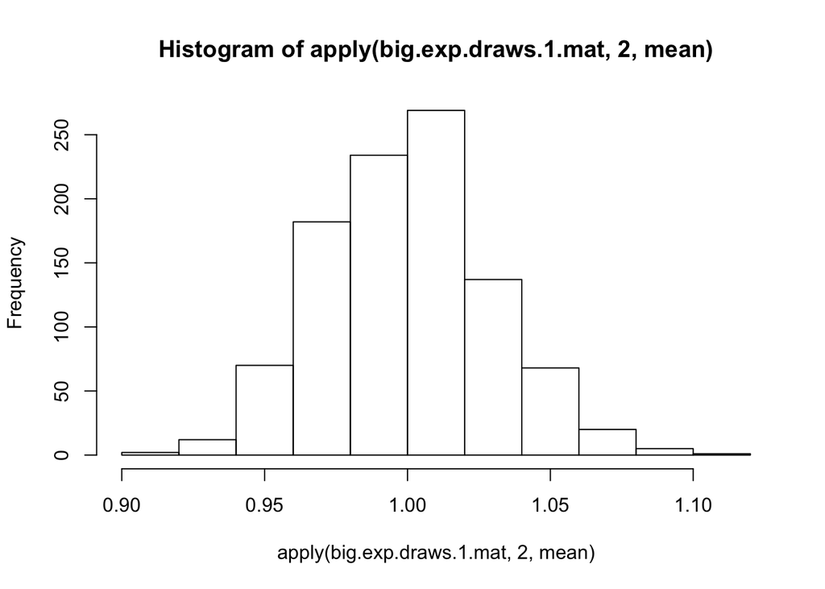

The histogram in problem 5b plots a histogram of the distribution, while the histogram in problem 5f plots a histogram of the means of a distribution. The histogram in 5f is approximately normally distributed, as we would expect from the Central Limit Theorem.